# Trabalho_metodos

Grupo Nos

07/12/2019

## Perceber o balanceamento das variáveis

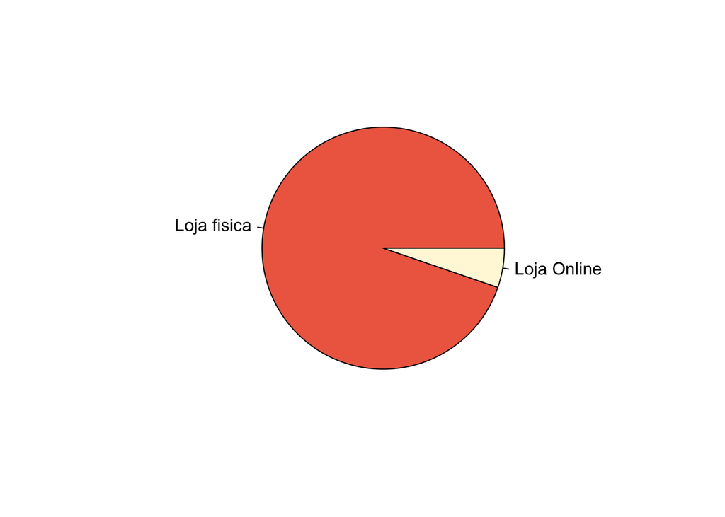

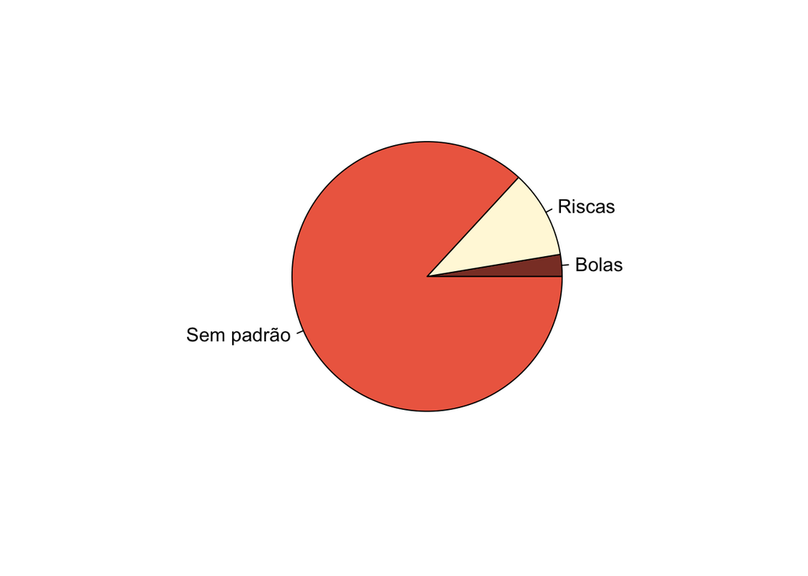

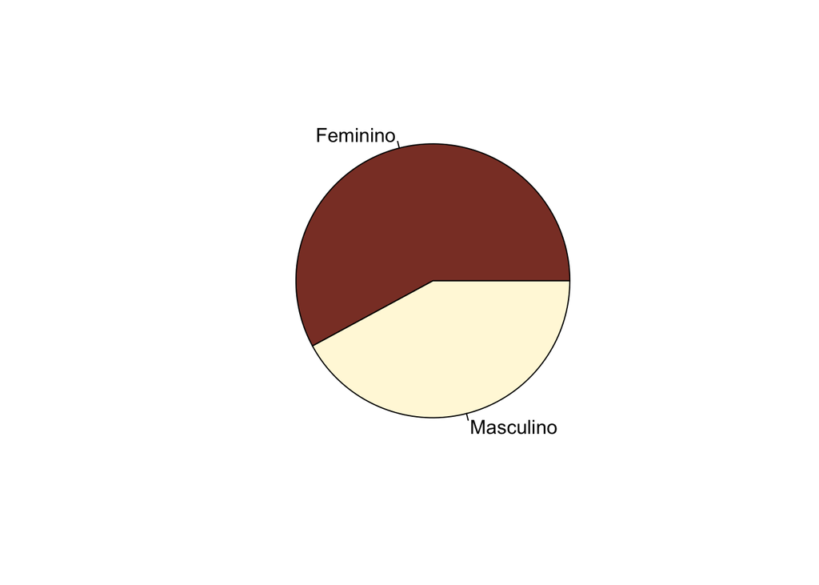

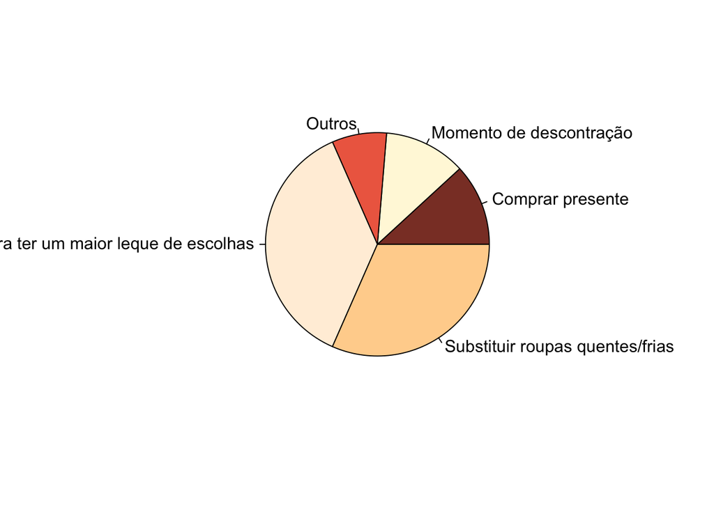

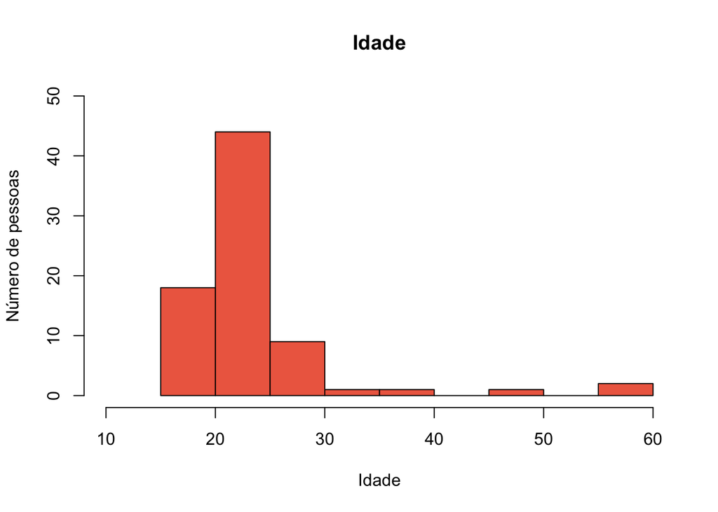

Maioria das pessoas da amostra(?) em estudo compram em loja fisica Preferência predominante para ausência de padrão Mais pessoas do sexo feminino, apesar que estái quase 50/50 Os motivos principais: Maior leque de escolhas e substituir roupas

## Tudo comparado à Idade

### Idade vs frequencia

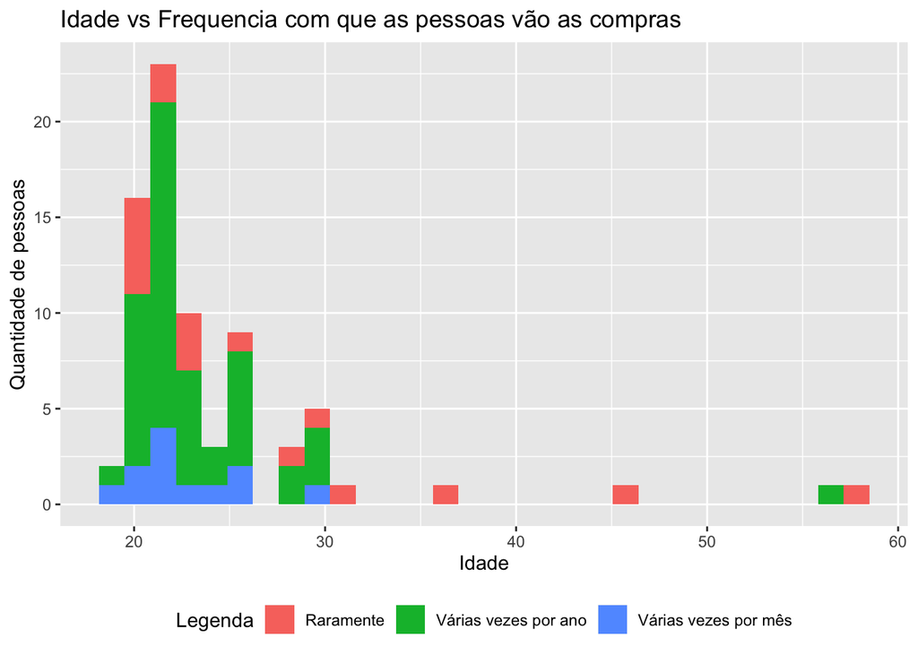

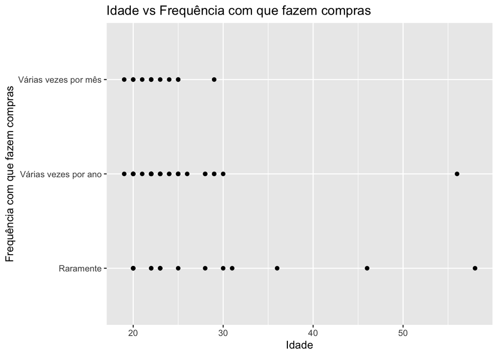

Percebe-se que em idades inferiores as pessoas compram roupa com mais frequência.

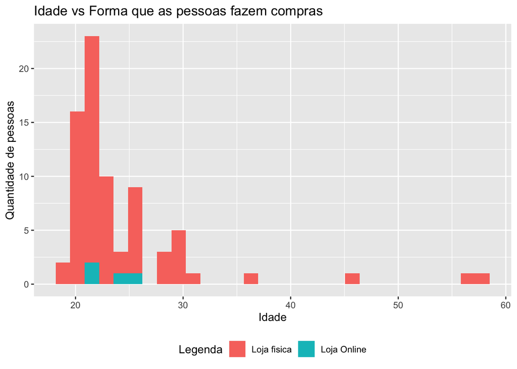

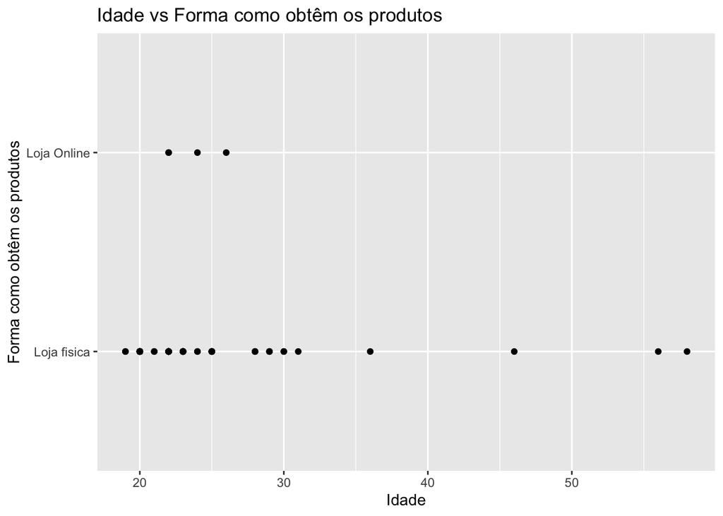

Compras em lojas online estão associadas a idades mais jovens.

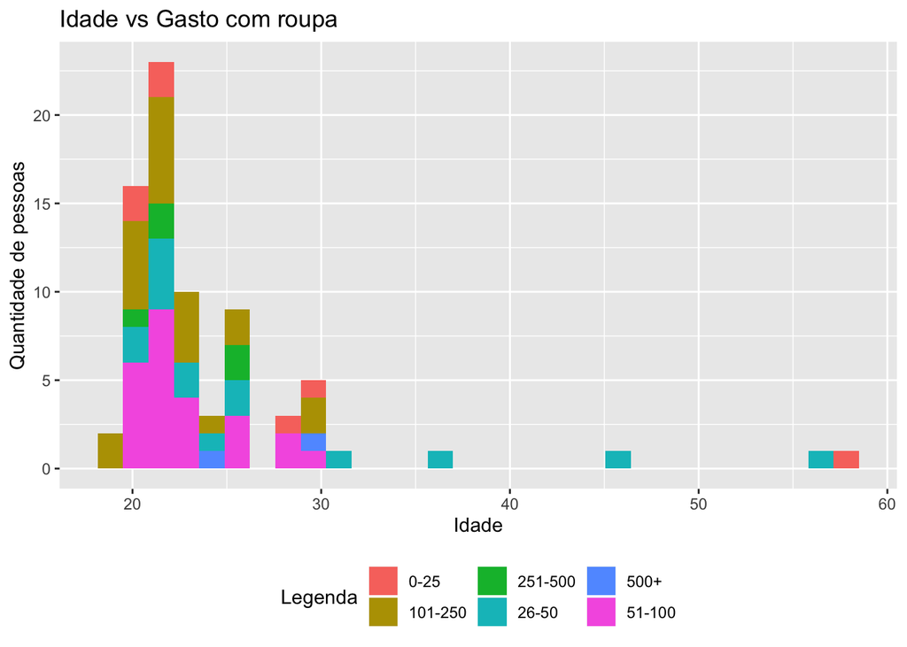

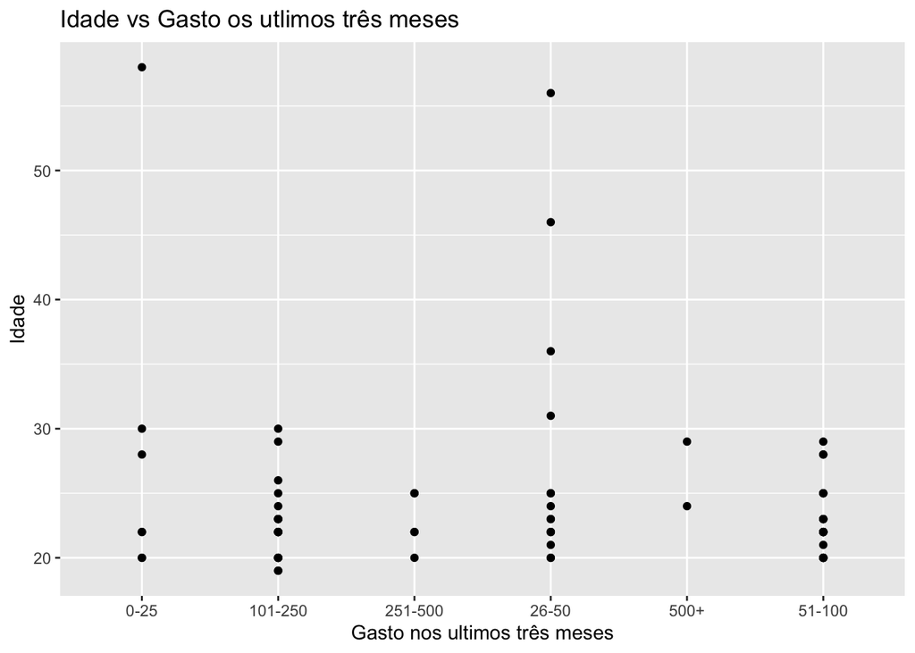

Os jovens gastam mais dinheiro em roupa,até aos 30 anos.

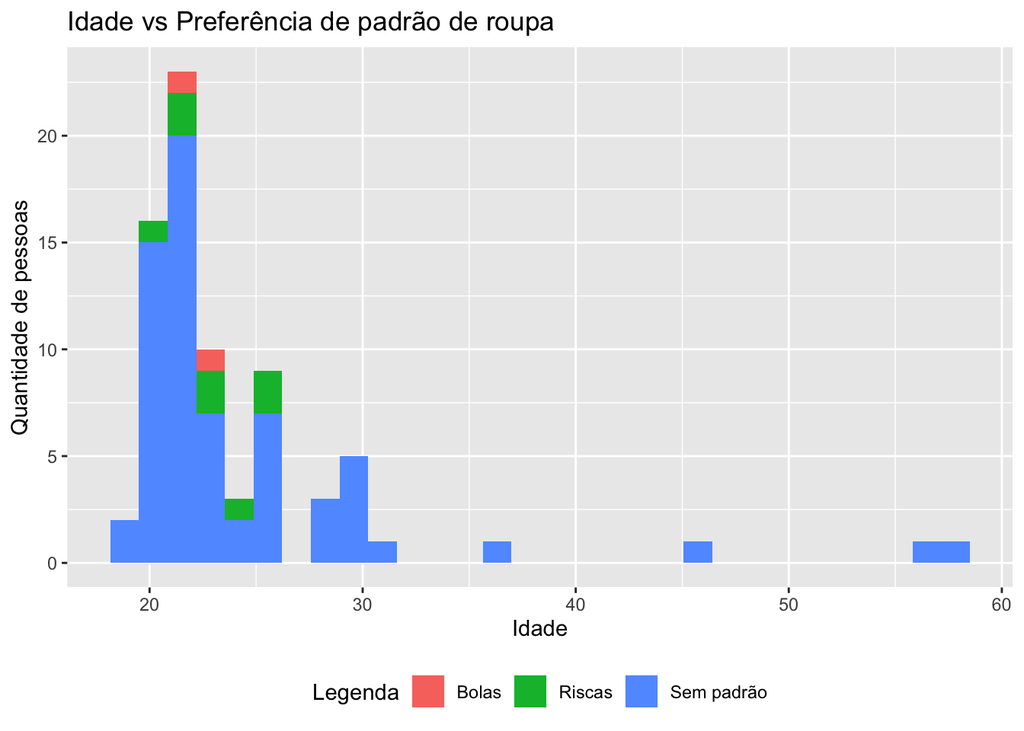

[figure not shown]

Apesar de a maioria preferir sem padrão, pessoas com idades inferiores, jovens até aos 25, preferem pardrões (Riscas ou Bolas) quando comprados com idades mais elevadas.

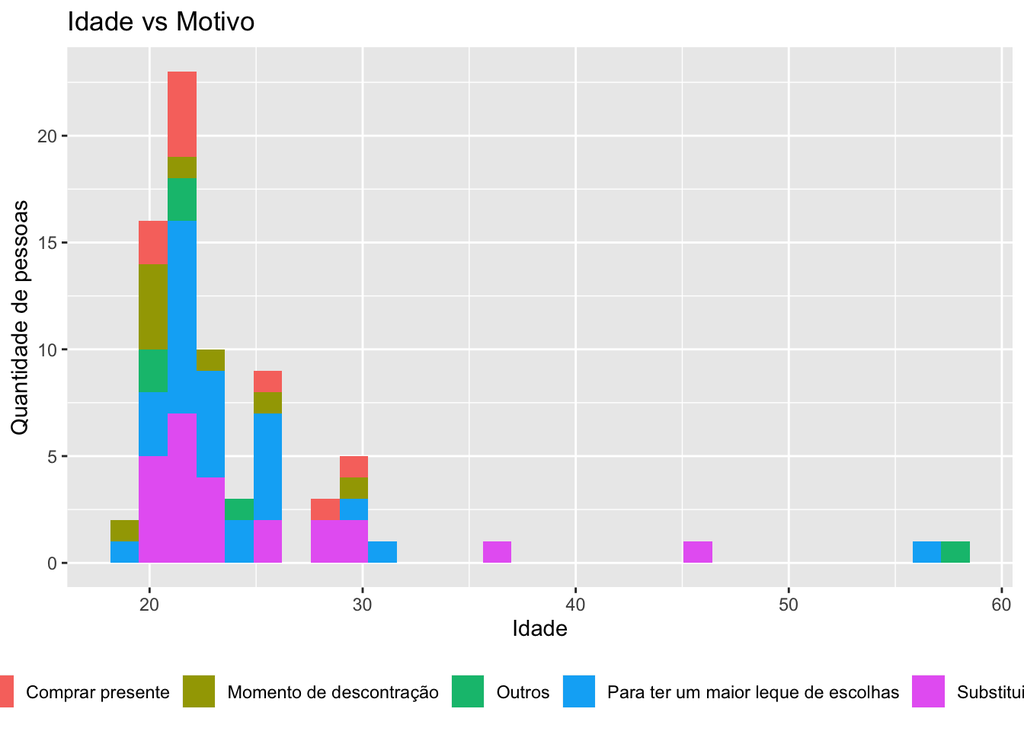

[figure not shown]

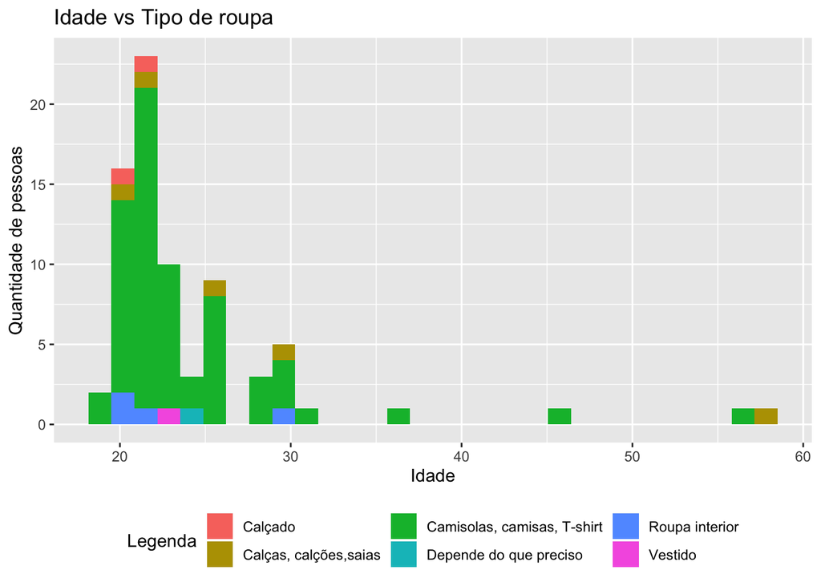

[figure not shown]

Não diz nada de jeito.

#Tabela de dupla entrada motivo vs Genero Tirar print com o view

```r
tabela= table(Genero,Motivo)
Total_linha<-margin.table(tabela,2)  # O argumento 2 define a marginal da linha
Total_coluna<-margin.table(tabela,1) # O argumento 1 define a marginal da coluna
Total_linha
```

```
## Motivo
##                    Comprar presente             Momento de descontração
##                                   9                                   9
##                              Outros Para ter um maior leque de escolhas
##                                   6                                  28
##     Substituir roupas quentes/frias
##                                  24
```

```r
Total_coluna
```

```
## Genero
##  Feminino Masculino
##        44        32
```

```r
ola<-rbind(cbind(tabela,Total_coluna),c(Total_linha, sum(Total_coluna)))
dimnames(ola)[[1]][3]<-"Total_linha"
ola
```

```
##             Comprar presente Momento de descontração Outros
## Feminino                   4                       8      4
## Masculino                  5                       1      2
## Total_linha                9                       9      6
##             Para ter um maior leque de escolhas
## Feminino                                     15
## Masculino                                    13
## Total_linha                                  28
##             Substituir roupas quentes/frias Total_coluna
## Feminino                                 13           44
## Masculino                                11           32
## Total_linha                              24           76
```

```r
tabela2=data.frame(ola)
tabela2
```

```
##             Comprar.presente Momento.de.descontração Outros
## Feminino                   4                       8      4
## Masculino                  5                       1      2
## Total_linha                9                       9      6
##             Para.ter.um.maior.leque.de.escolhas
## Feminino                                     15
## Masculino                                    13
## Total_linha                                  28
##             Substituir.roupas.quentes.frias Total_coluna
## Feminino                                 13           44
## Masculino                                11           32
## Total_linha                              24           76
```

```r
names(tabela2)[1]<-"Comprar um presente"
names(tabela2)[2]="Momento de descontração"
names(tabela2)[3]="Outros"
names(tabela2)[4]="Para ter um maior leque de escolhas"
names(tabela2)[5]="Substituir roupas quentes por frias"

tabela2
```

```
##             Comprar um presente Momento de descontração Outros
## Feminino                      4                       8      4
## Masculino                     5                       1      2
## Total_linha                   9                       9      6
##             Para ter um maior leque de escolhas
## Feminino                                     15
## Masculino                                    13
## Total_linha                                  28
##             Substituir roupas quentes por frias Total_coluna
## Feminino                                     13           44
## Masculino                                    11           32
## Total_linha                                  24           76
```

```r
View(tabela2)
#rm(tabela2)
tabela2=subset(tabela2, select=c(1,2,4,5,3,6))
View(tabela2)
```

## Tudo comparado ao género

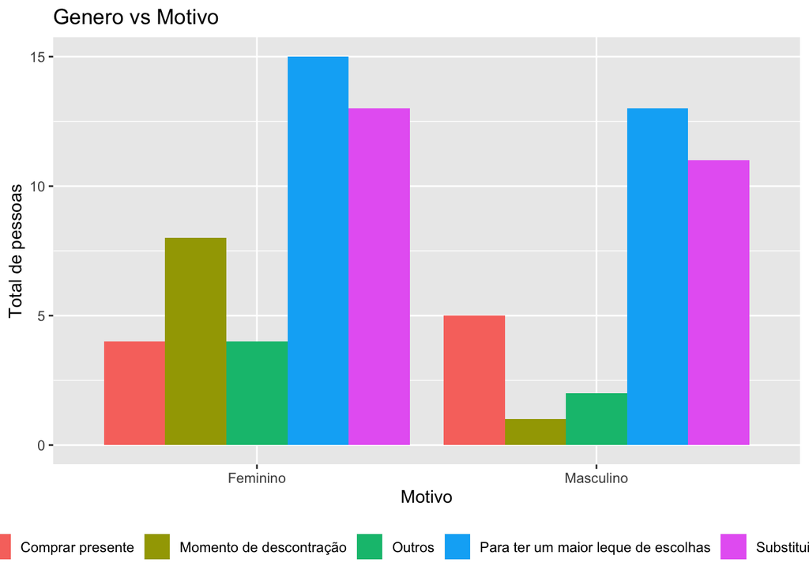

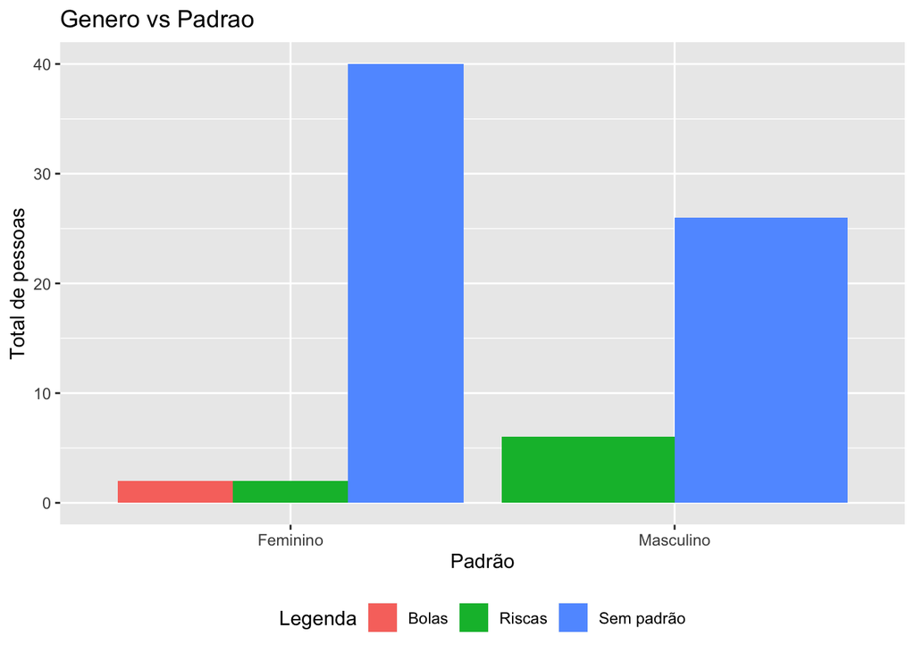

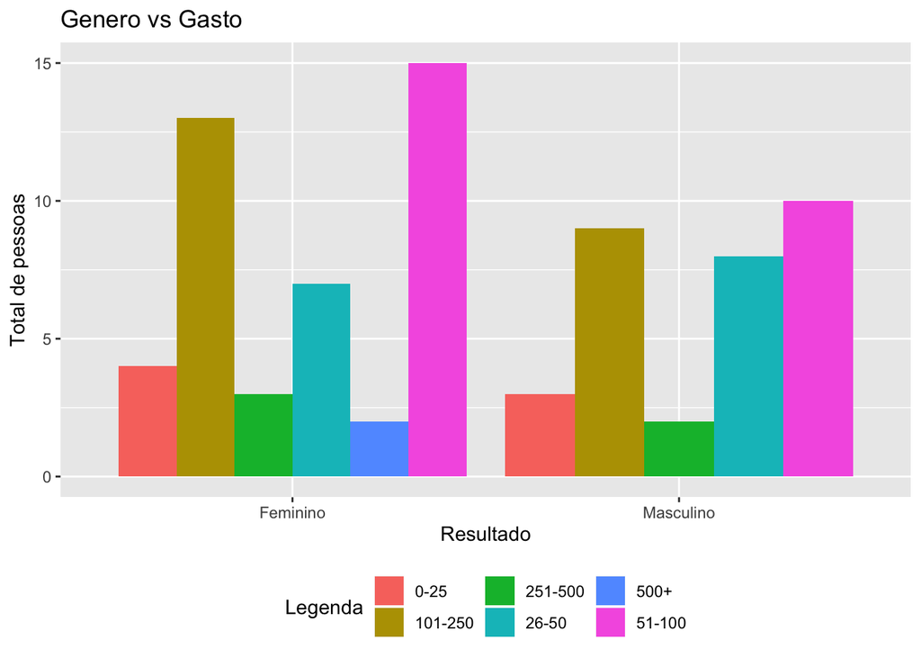

tirar print com o view

```r
tabela_gp= table(Genero,Padrao)
Total_linha_1<-margin.table(tabela_gp,2)  # O argumento 2 define a marginal da linha
Total_coluna_1<-margin.table(tabela_gp,1) # O argumento 1 define a marginal da coluna
simx<-rbind(cbind(tabela_gp,Total_coluna_1),c(Total_linha_1, sum(Total_coluna)))
dimnames(simx)[[1]][3]<-"Total_linha"
simx
```

```
##             Bolas Riscas Sem padrão Total_coluna_1
## Feminino        2      2         40             44
## Masculino       0      6         26             32
## Total_linha     2      8         66             76
```

```r
tabela3=data.frame(simx)
tabela3
```

```
##             Bolas Riscas Sem.padrão Total_coluna_1
## Feminino        2      2         40             44
## Masculino       0      6         26             32
## Total_linha     2      8         66             76
```

```r
names(tabela3)[1]<-"Bolas"
names(tabela3)[2]="Riscas"
names(tabela3)[3]="Sem padrão"
names(tabela3)[4]="Total_coluna"

View(tabela3)
```